# Rowley - VWR - Phonological Priming

## Visualization

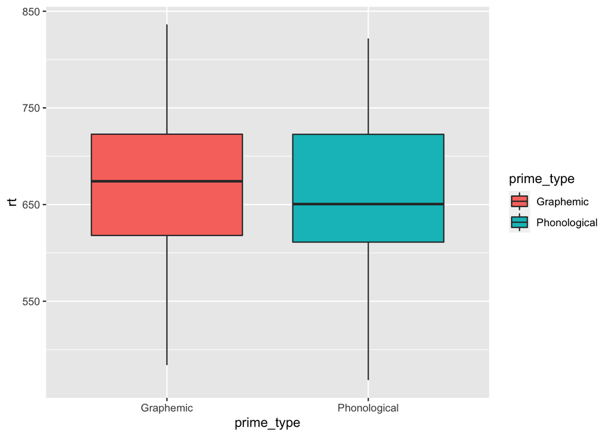

```r
subject_level %>%
  ggplot(aes(x = prime_type, y = rt, fill = prime_type)) +
  geom_boxplot() +
  scale_y_continuous()
```

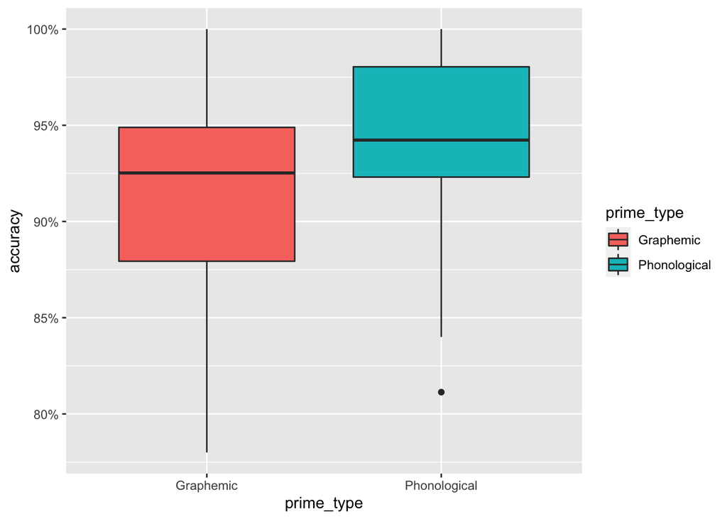

```r
subject_level %>%
  ggplot(aes(x = prime_type, y = accuracy, fill = prime_type)) +
  geom_boxplot() +
  scale_y_continuous(labels = percent_format(1))
```

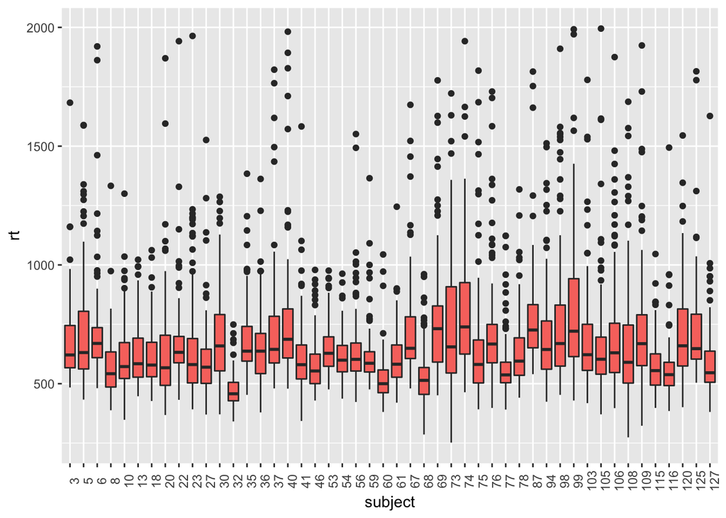

```r
hearing_df %>%
  ggplot(aes(x = subject, y = rt, fill = group)) +
  geom_boxplot() +
  guides(fill = F) +
  theme(axis.text.x = element_text(angle = 90))
```

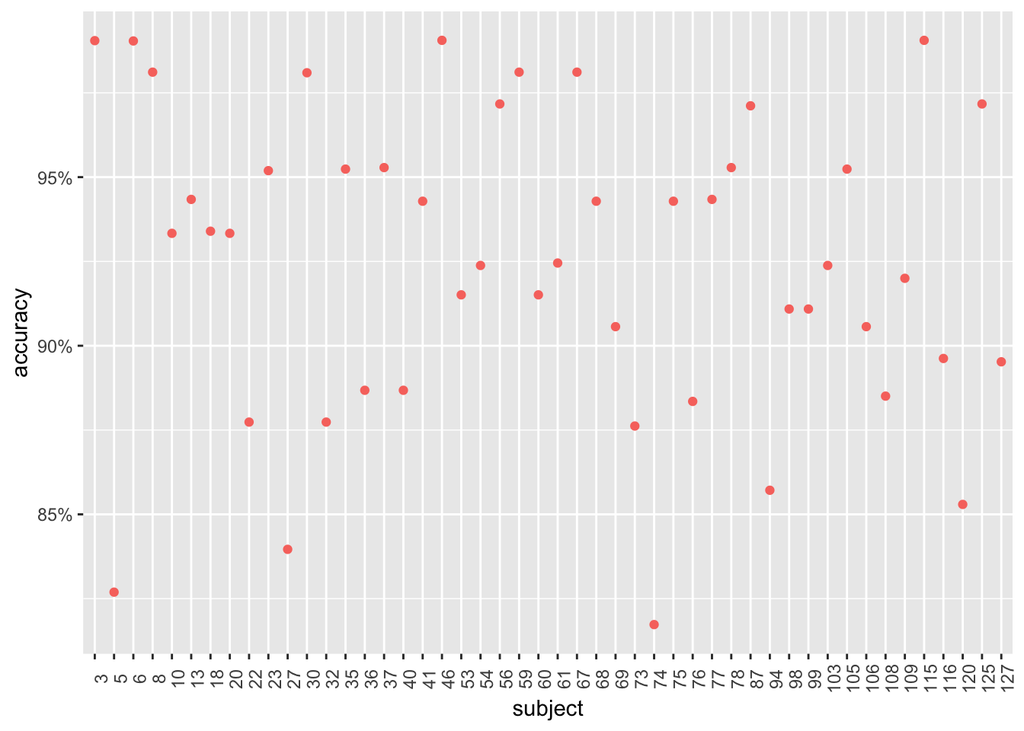

```r
hearing_df %>%
  group_by(group, subject) %>%
  summarise(accuracy = mean(accuracy)) %>%
  ggplot(aes(x = subject, y = accuracy, color = group)) +
  geom_point() +
  guides(color = F) +
  scale_y_continuous(labels = percent_format(1)) +
  theme(axis.text.x = element_text(angle = 90))
```

## Modeling

To set up our linear mixed effects (also called hierarchical regression, multilevel models, etc.) we need to decide what are the fixed effects (the ones we are interested in) and what are the random effects (what we are not interested in, but which variance should be accounted for in our model).

Models for:

1. Reaction time
2. Accuracy

In each model, the fixed effect is:

1. Prime Type (phonological/graphemic)

And the random effects are:

### Reaction Time Model

```r
rt_model <- lmer(data = hearing_df, rt ~ prime_type + running_trial +
                                         (1|subject) + (1|target_trial))
tab_model(rt_model)
```

|  | rt |  |  |
| --- | --- | --- | --- |
| Predictors | Estimates | CI | p |
| (Intercept) | 682.71 | 650.23 – 715.20 | **<0.001** |
| prime_type [Phonological] | -9.93 | -20.70 – 0.84 | 0.071 |
| running_trial [ListB] | -25.28 | -68.47 – 17.91 | 0.251 |
| Random Effects |  |  |  |
| σ<sup>2</sup> | 37878.29 |  |  |
| τ<sub>00</sub> <sub>target_trial</sub> | 2632.09 |  |  |
| τ<sub>00</sub> <sub>subject</sub> | 5463.99 |  |  |
| ICC | 0.18 |  |  |
| N <sub>subject</sub> | 48 |  |  |
| N <sub>target_trial</sub> | 106 |  |  |
| Observations | 5022 |  |  |
| Marginal R<sup>2</sup> / Conditional R<sup>2</sup> | 0.004 / 0.179 |  |  |

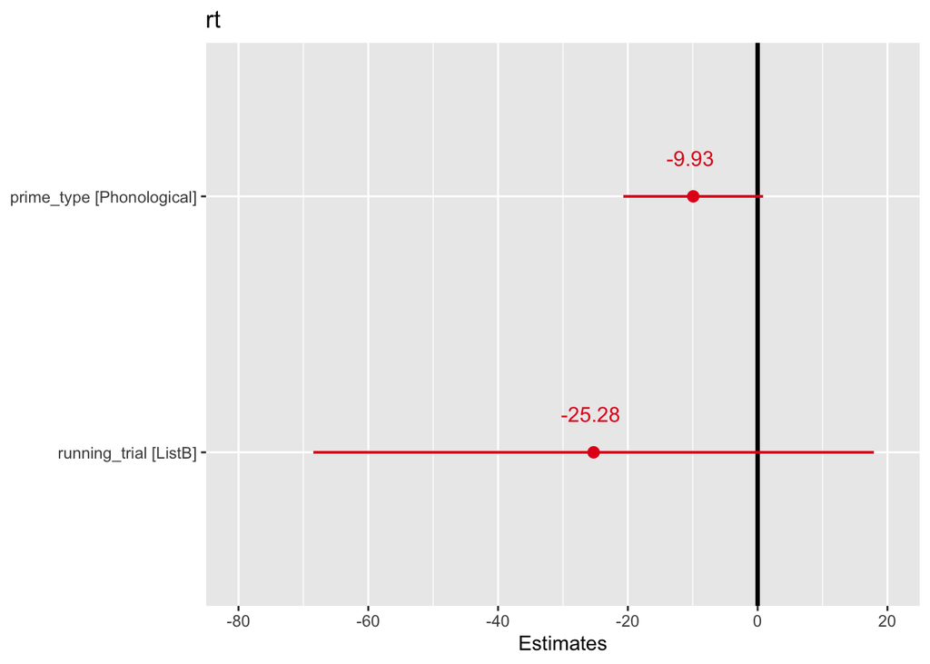

```r
plot_model(rt_model, vline.color = 'black',  show.values = TRUE)
```

### Accuracy Model

```r
acc_model <- lmer(data = hearing_df, accuracy ~ prime_type + running_trial +
                                         (1|subject) + (1|target_trial))

tab_model(acc_model)
```

|  | accuracy |  |  |
| --- | --- | --- | --- |
| Predictors | Estimates | CI | p |
| (Intercept) | 0.92 | 0.90 – 0.95 | **<0.001** |
| prime_type [Phonological] | 0.02 | 0.01 – 0.04 | **0.001** |
| running_trial [ListB] | -0.02 | -0.04 – 0.01 | 0.161 |
| Random Effects |  |  |  |
| σ<sup>2</sup> | 0.06 |  |  |
| τ<sub>00</sub> <sub>target_trial</sub> | 0.01 |  |  |
| τ<sub>00</sub> <sub>subject</sub> | 0.00 |  |  |
| ICC | 0.10 |  |  |
| N <sub>subject</sub> | 48 |  |  |
| N <sub>target_trial</sub> | 106 |  |  |
| Observations | 5022 |  |  |
| Marginal R<sup>2</sup> / Conditional R<sup>2</sup> | 0.003 / 0.101 |  |  |

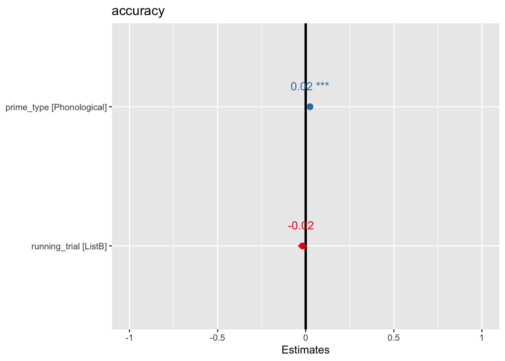

```r
plot_model(acc_model, vline.color = 'black',  show.values = TRUE)
```